# CodesRUs Final Report

March 9, 2022

```
##   match.id             team1                  team2 winner team1.goals
## 1  2499719           Arsenal         Leicester City  team1           4
## 2  2499720   Manchester City Brighton & Hove Albion  team1           1
## 3  2499721           Burnley                Chelsea  team1           3
## 4  2499722    Crystal Palace      Huddersfield Town  team2           0
## 5  2499723        Stoke City                Everton  team2           0
## 6  2499724 Manchester United        West Ham United  team1           4
##   team2.goals team1.shots team2.shots team1.shots.target team2.shots.target
## 1           3          27           7                 10                  4
## 2           0          12           6                  3                  2
## 3           2           9          15                  5                  5
## 4           2          11           8                  3                  6
## 5           1          10           8                  1                  3
## 6           0          21           7                  5                  1
##   team1.passes team2.passes team1.pass.acc team2.pass.acc team1.possession
```

[output cut: 20 more lines]

```
## 'data.frame':    1941 obs. of  26 variables:
##  $ match.id          : int  2499719 2499720 2499721 2499722 2499723 2499724 2499725 2499726 2499727 2499728 ...
##  $ team1             : chr  "Arsenal" "Manchester City" "Burnley" "Crystal Palace" ...
##  $ team2             : chr  "Leicester City" "Brighton & Hove Albion" "Chelsea" "Huddersfield Town" ...
##  $ winner            : chr  "team1" "team1" "team1" "team2" ...
##  $ team1.goals       : int  4 1 3 0 0 4 2 0 3 1 ...
##  $ team2.goals       : int  3 0 2 2 1 0 0 0 2 0 ...
##  $ team1.shots       : int  27 12 9 11 10 21 17 4 8 16 ...
##  $ team2.shots       : int  7 6 15 8 8 7 5 25 12 8 ...
##  $ team1.shots.target: int  10 3 5 3 1 5 7 0 4 6 ...
##  $ team2.shots.target: int  4 2 5 6 3 1 3 2 4 2 ...
##  $ team1.passes      : int  513 682 245 291 205 404 630 278 290 166 ...
##  $ team2.passes      : int  166 124 454 194 406 306 160 427 360 534 ...
##  $ team1.pass.acc    : num  84.7 90.5 82.8 78.6 76.8 ...
##  $ team2.pass.acc    : num  72.2 67.4 88 71.1 84.2 ...
##  $ team1.possession  : num  50.3 59.7 50.4 47.6 47.7 ...
##  $ team2.possession  : num  49.7 40.3 49.6 52.4 52.3 ...
##  $ team1.corners     : int  9 10 5 12 7 11 7 0 3 8 ...
##  $ team2.corners     : int  4 3 8 9 6 1 5 13 3 2 ...
##  $ team1.offsides    : int  6 1 1 0 6 1 2 1 3 2 ...
##  $ team2.offsides    : int  2 6 2 2 2 4 2 0 1 0 ...
##  $ team1.fouls       : int  9 9 11 7 10 19 9 13 13 15 ...
##  $ team2.fouls       : int  12 6 18 19 13 7 8 11 10 4 ...
##  $ team1.yellows     : int  0 2 3 1 1 2 2 1 0 3 ...
##  $ team2.yellows     : int  1 0 5 3 1 2 1 2 3 1 ...
##  $ team1.reds        : int  0 0 0 0 0 0 0 0 0 0 ...
##  $ team2.reds        : int  0 0 1 0 0 0 1 0 0 0 ...
```

In order to analyze a particular variable (e.g. # goals), we need to transform the dataset from wide to long. This way, each match-team combination will have a corresponding # goals value stored in the same column.

```
## 'data.frame':    1941 obs. of  12 variables:
##  $ team1             : chr  "Arsenal" "Manchester City" "Burnley" "Crystal Palace" ...
##  $ team1.goals       : int  4 1 3 0 0 4 2 0 3 1 ...
##  $ team1.shots       : int  27 12 9 11 10 21 17 4 8 16 ...
##  $ team1.shots.target: int  10 3 5 3 1 5 7 0 4 6 ...
##  $ team1.passes      : int  513 682 245 291 205 404 630 278 290 166 ...
##  $ team1.pass.acc    : num  84.7 90.5 82.8 78.6 76.8 ...
##  $ team1.possession  : num  50.3 59.7 50.4 47.6 47.7 ...
##  $ team1.corners     : int  9 10 5 12 7 11 7 0 3 8 ...
##  $ team1.offsides    : int  6 1 1 0 6 1 2 1 3 2 ...
##  $ team1.fouls       : int  9 9 11 7 10 19 9 13 13 15 ...
##  $ team1.yellows     : int  0 2 3 1 1 2 2 1 0 3 ...
##  $ team1.reds        : int  0 0 0 0 0 0 0 0 0 0 ...
```

```
## 'data.frame':    1941 obs. of  12 variables:
##  $ team2             : chr  "Leicester City" "Brighton & Hove Albion" "Chelsea" "Huddersfield Town" ...
##  $ team2.goals       : int  3 0 2 2 1 0 0 0 2 0 ...
##  $ team2.shots       : int  7 6 15 8 8 7 5 25 12 8 ...
##  $ team2.shots.target: int  4 2 5 6 3 1 3 2 4 2 ...
##  $ team2.passes      : int  166 124 454 194 406 306 160 427 360 534 ...
##  $ team2.pass.acc    : num  72.2 67.4 88 71.1 84.2 ...
##  $ team2.possession  : num  49.7 40.3 49.6 52.4 52.3 ...
##  $ team2.corners     : int  4 3 8 9 6 1 5 13 3 2 ...
##  $ team2.offsides    : int  2 6 2 2 2 4 2 0 1 0 ...
##  $ team2.fouls       : int  12 6 18 19 13 7 8 11 10 4 ...
##  $ team2.yellows     : int  1 0 5 3 1 2 1 2 3 1 ...
##  $ team2.reds        : int  0 0 1 0 0 0 1 0 0 0 ...
```

```
## 'data.frame':    3882 obs. of  12 variables:
##  $ team        : chr  "Arsenal" "Manchester City" "Burnley" "Crystal Palace" ...
##  $ goals       : int  4 1 3 0 0 4 2 0 3 1 ...
##  $ shots       : int  27 12 9 11 10 21 17 4 8 16 ...
##  $ shots.target: int  10 3 5 3 1 5 7 0 4 6 ...
##  $ passes      : int  513 682 245 291 205 404 630 278 290 166 ...
##  $ pass.acc    : num  84.7 90.5 82.8 78.6 76.8 ...
##  $ possession  : num  50.3 59.7 50.4 47.6 47.7 ...
##  $ corners     : int  9 10 5 12 7 11 7 0 3 8 ...
##  $ offsides    : int  6 1 1 0 6 1 2 1 3 2 ...
##  $ fouls       : int  9 9 11 7 10 19 9 13 13 15 ...
##  $ yellows     : int  0 2 3 1 1 2 2 1 0 3 ...
##  $ reds        : int  0 0 0 0 0 0 0 0 0 0 ...
```

The dataset teams now has 3,882 records that can be used to analyze number of goals and the factors that influence it. We will run various linear regression models and evaluate them against one another. For this exercise, we will only use continuous variables and then check adjusted R squared and BIC to compare models.

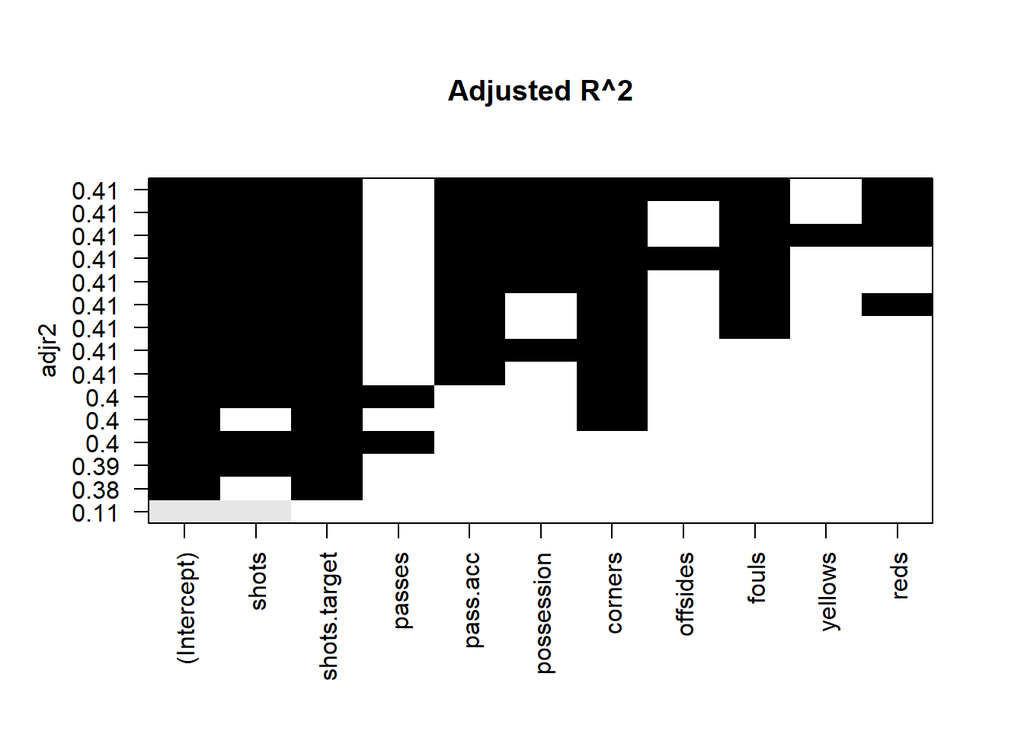

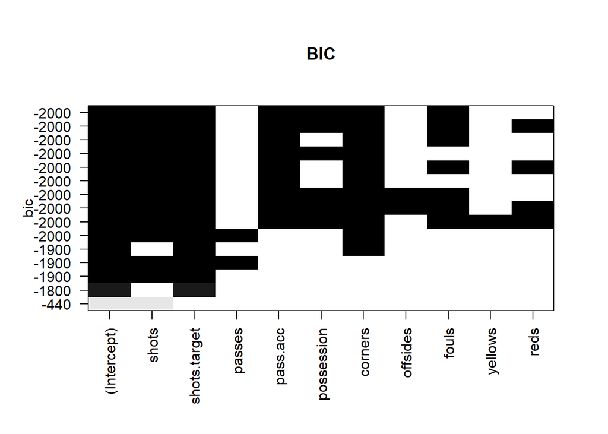

```
##
## Call:
## lm(formula = goals ~ shots + shots.target + pass.acc + possession +
##     corners + fouls, data = teams_cont)
##
## Residuals:
##    Min     1Q Median     3Q    Max
## -3.164 -0.597 -0.072  0.533  3.536
##
## Coefficients:
##              Estimate Std. Error t value Pr(>|t|)
## (Intercept)  -0.50536    0.24978   -2.02  0.04312 *
## shots        -0.03436    0.00480   -7.16  9.7e-13 ***
## shots.target  0.34968    0.00836   41.84  < 2e-16 ***
## pass.acc      0.01896    0.00314    6.05  1.6e-09 ***
## possession   -0.01052    0.00314   -3.35  0.00081 ***
## corners      -0.03999    0.00624   -6.41  1.6e-10 ***
## fouls        -0.01219    0.00345   -3.54  0.00041 ***
## ---
## Signif. codes:  0 '***' 0.001 '**' 0.01 '*' 0.05 '.' 0.1 ' ' 1
##
## Residual standard error: 0.9 on 3875 degrees of freedom
## Multiple R-squared:  0.409,  Adjusted R-squared:  0.408
## F-statistic:  448 on 6 and 3875 DF,  p-value: <2e-16
```

```
##        shots shots.target     pass.acc   possession      corners        fouls
##         2.53         1.93         1.40         1.31         1.46         1.07
```

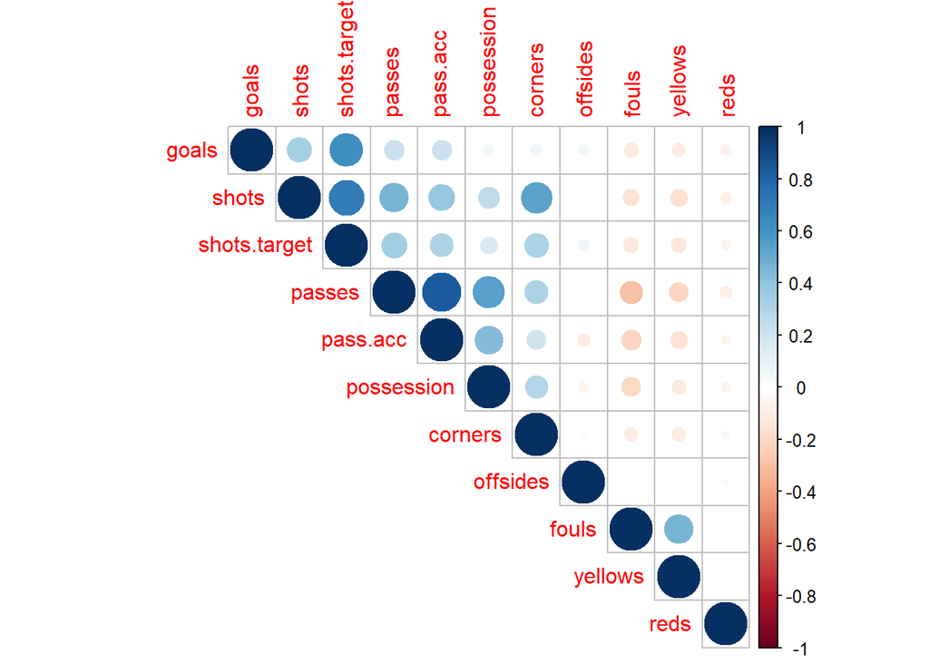

Now we want to see whether we can incorporate these variables without worrying about multicollinearity. We may be able to do that using PCA/PCR.

Table

|  | PC1 | PC2 | PC3 | PC4 | PC5 | PC6 | PC7 | PC8 | PC9 | PC10 | PC11 |
| --- | --- | --- | --- | --- | --- | --- | --- | --- | --- | --- | --- |
| goals | -0.2609 | 0.4444 | -0.2271 | 0.4388 | -0.0561 | 0.1616 | -0.3134 | 0.0470 | 0.5033 | 0.3274 | -0.0126 |
| shots | -0.4117 | 0.2871 | 0.0453 | -0.1687 | 0.1542 | -0.1977 | 0.2007 | -0.0448 | -0.4856 | 0.6110 | 0.0572 |
| shots.target | -0.3763 | 0.4697 | -0.1082 | 0.1163 | 0.0824 | -0.0141 | -0.0629 | 0.0244 | -0.3321 | -0.7005 | -0.0045 |
| passes | -0.4416 | -0.2599 | 0.1933 | 0.0842 | -0.0947 | 0.2318 | 0.2323 | -0.0312 | 0.0707 | -0.0194 | -0.7550 |
| pass.acc | -0.3981 | -0.2600 | 0.2287 | 0.2435 | -0.0490 | 0.2574 | 0.3995 | -0.0609 | 0.1472 | -0.0782 | 0.6345 |
| possession | -0.3062 | -0.3280 | 0.2806 | -0.1183 | -0.0438 | 0.0904 | -0.7447 | 0.2984 | -0.1879 | 0.0402 | 0.1237 |
| corners | -0.2906 | 0.1036 | 0.1705 | -0.5809 | 0.2191 | -0.3612 | -0.0111 | -0.0940 | 0.5748 | -0.1392 | 0.0326 |
| offsides | 0.0008 | 0.2286 | -0.1847 | -0.5808 | -0.4061 | 0.6314 | 0.0611 | 0.0605 | -0.0083 | 0.0246 | 0.0685 |
| fouls | 0.2205 | 0.3353 | 0.5527 | 0.0556 | 0.0650 | 0.0522 | 0.2132 | 0.6861 | 0.0721 | 0.0078 | -0.0451 |
| yellows | 0.1909 | 0.2761 | 0.6158 | 0.0538 | -0.0011 | 0.2107 | -0.1987 | -0.6465 | -0.0541 | 0.0131 | -0.0181 |
| reds | 0.0641 | -0.0713 | -0.1359 | -0.0657 | 0.8578 | 0.4798 | -0.0247 | 0.0169 | 0.0024 | 0.0209 | -0.0240 |

```
## Data:    X dimension: 3882 10
##  Y dimension: 3882 1
## Fit method: svdpc
## Number of components considered: 10
##
## VALIDATION: RMSEP
## Cross-validated using 10 random segments.
##        (Intercept)  1 comps  2 comps  3 comps  4 comps  5 comps  6 comps
## CV            1.17    1.095    1.075    1.054    1.054    1.052   0.9729
## adjCV         1.17    1.095    1.074    1.054    1.054    1.052   0.9728
##        7 comps  8 comps  9 comps  10 comps
## CV      0.9476   0.9456   0.9005    0.9006
## adjCV   0.9472   0.9454   0.9004    0.9004
##
## TRAINING: % variance explained
##        1 comps  2 comps  3 comps  4 comps  5 comps  6 comps  7 comps  8 comps
## X        32.72    46.23    58.26    68.26    77.66    85.45    90.87    96.01
## goals    12.44    15.73    19.01    19.01    19.36    31.07    34.65    34.96
##        9 comps  10 comps
## X        98.58    100.00
## goals    41.06     41.07
```

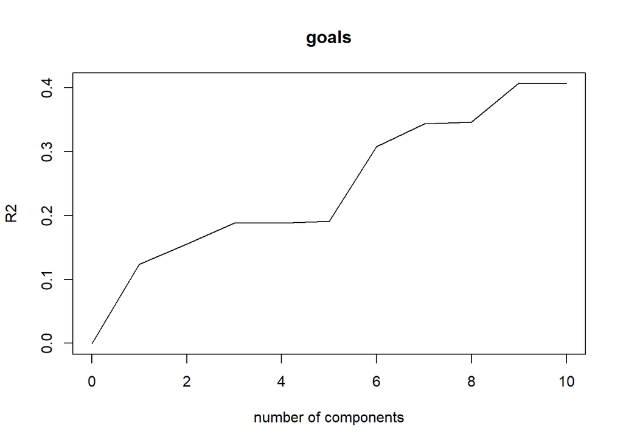

```
##      PC1    PC2    PC3    PC4    PC5     PC6    PC7     PC8    PC9    PC10
## 1 -4.049  1.588 -2.929 -0.552 -0.736 -0.6087  0.139 -0.2176  0.732 -0.1640
## 2 -3.263 -0.875  1.722 -0.061 -0.326  1.3556  0.475  0.7633 -0.288 -0.6522
## 3  0.340  0.103  0.253  0.148  0.576  0.0189 -0.787  0.6308 -0.593  0.7413
## 4 -0.505 -0.441 -1.110  0.700  1.597  2.0433  0.692  1.2550 -0.537  0.0667
## 5  1.085 -0.270 -1.971 -1.212 -1.123  1.3662  0.577  0.2642  0.442  0.5242
## 6 -1.907  2.092  0.266  0.815  0.873  0.4941  1.573 -0.0632  0.553  0.4158
##   goals
## 1     4
## 2     1
## 3     3
## 4     0
## 5     0
## 6     4
```

Full model using Principal Comps

|  | Estimate | Std. Error | t value | Pr(>\|t\|) |
| --- | --- | --- | --- | --- |
| (Intercept) | 1.1558 | 0.0144 | 80.093 | 0.000 |
| PC1 | -0.2281 | 0.0080 | -28.585 | 0.000 |
| PC2 | 0.1825 | 0.0124 | 14.700 | 0.000 |
| PC3 | -0.1931 | 0.0132 | -14.677 | 0.000 |
| PC4 | 0.0023 | 0.0144 | 0.159 | 0.874 |
| PC5 | 0.0720 | 0.0149 | 4.837 | 0.000 |
| PC6 | -0.4534 | 0.0164 | -27.727 | 0.000 |
| PC7 | -0.3009 | 0.0196 | -15.346 | 0.000 |
| PC8 | -0.0906 | 0.0201 | -4.500 | 0.000 |
| PC9 | -0.5702 | 0.0285 | -20.011 | 0.000 |
| PC10 | 0.0330 | 0.0383 | 0.861 | 0.389 |

```
##
## Call:
## lm(formula = goals ~ ., data = teamsscaled.pc)
##
## Residuals:
##    Min     1Q Median     3Q    Max
## -3.166 -0.598 -0.074  0.534  3.519
##
## Coefficients:
##             Estimate Std. Error t value Pr(>|t|)
## (Intercept)  1.15585    0.01443   80.09  < 2e-16 ***
## PC1         -0.22809    0.00798  -28.59  < 2e-16 ***
## PC2          0.18254    0.01242   14.70  < 2e-16 ***
## PC3         -0.19312    0.01316  -14.68  < 2e-16 ***
## PC4          0.00229    0.01443    0.16     0.87
## PC5          0.07200    0.01489    4.84  1.4e-06 ***
## PC6         -0.45338    0.01635  -27.73  < 2e-16 ***
## PC7         -0.30087    0.01961  -15.35  < 2e-16 ***
## PC8         -0.09059    0.02013   -4.50  7.0e-06 ***
## PC9         -0.57023    0.02850  -20.01  < 2e-16 ***
## PC10         0.03298    0.03831    0.86     0.39
## ---
## Signif. codes:  0 '***' 0.001 '**' 0.01 '*' 0.05 '.' 0.1 ' ' 1
##
## Residual standard error: 0.899 on 3871 degrees of freedom
## Multiple R-squared:  0.411,  Adjusted R-squared:  0.409
## F-statistic:  270 on 10 and 3871 DF,  p-value: <2e-16
```

Limited model using Principal Comps

|  | Estimate | Std. Error | t value | Pr(>\|t\|) |
| --- | --- | --- | --- | --- |
| (Intercept) | 1.156 | 0.0162 | 71.2 | 0 |
| PC1 | -0.228 | 0.0090 | -25.4 | 0 |
| PC2 | 0.182 | 0.0140 | 13.1 | 0 |
| PC7 | -0.301 | 0.0220 | -13.7 | 0 |
| PC9 | -0.570 | 0.0320 | -17.8 | 0 |

```
##
## Call:
## lm(formula = goals ~ PC1 + PC2 + PC7 + PC9, data = teamsscaled.pc)
##
## Residuals:
##    Min     1Q Median     3Q    Max
## -3.130 -0.687 -0.137  0.575  4.352
##
## Coefficients:
##             Estimate Std. Error t value Pr(>|t|)
## (Intercept)  1.15585    0.01622    71.2   <2e-16 ***
## PC1         -0.22809    0.00897   -25.4   <2e-16 ***
## PC2          0.18254    0.01396    13.1   <2e-16 ***
## PC7         -0.30087    0.02204   -13.6   <2e-16 ***
## PC9         -0.57023    0.03203   -17.8   <2e-16 ***
## ---
## Signif. codes:  0 '***' 0.001 '**' 0.01 '*' 0.05 '.' 0.1 ' ' 1
##
## Residual standard error: 1.01 on 3877 degrees of freedom
## Multiple R-squared:  0.254,  Adjusted R-squared:  0.253
## F-statistic:  330 on 4 and 3877 DF,  p-value: <2e-16
```